# Transfer Learning Tests for Kaggle Fingers Dataset Using AWS Sagemaker

#### Context

- The goal of the project is to build a model able to count fingers as well as distinguish between left and right hand.

#### Content

- 21600 images of left and right hands fingers.
- All images are 128 by 128 pixels.
- Training set: 18000 images
- Test set: 3600 images
- Images are centered by the center of mass
- Noise pattern on the background

#### Labels

- Labels are in 2 last characters of a file name. L/R indicates left/right hand; 0,1,2,3,4,5 indicates number of fingers.

#### Note

- Images of a left hand were generated by flipping images of right hand.
- Later, the *training images* where divided in a *validation set* of 3600 images giving a training set of 14400 images

#### [Kaggle Fingers Dataset](https://www.kaggle.com/datasets/koryakinp/fingers)

#### PreInstall libraries that are functional with sagemaker debug and profiling

NOTE:

- This function will be deprecated on sagemaker>2.0
- WE WILL NOT TRAIN FOR THE WHOLE DATASET BECAUSE IS NOT NECCESARY AT ALL, THE MODEL PERFORMS WELL WITH 20% OF THE TOTAL EPOCH

```python
!pip install smdebug
!pip install --upgrade wandb==0.12.17
!pip install protobuf==3.19.0
!pip install --upgrade bokeh==2.4.3
```

[output not shown]

Resets the notebook for the pre-installed libraries to work

```python
from IPython.core.display import HTML
HTML("<script>Jupyter.notebook.kernel.restart()</script>") # reset the kernel
```

#### Load Important Libraries for HyperParameter Optimization and Training

```python
import sagemaker
import boto3
from sagemaker.pytorch import PyTorch
from io import BytesIO
import zipfile
from sagemaker.tuner import (
    IntegerParameter,
    CategoricalParameter,
    ContinuousParameter,
    HyperparameterTuner,
)
```

```
sagemaker.config INFO - Not applying SDK defaults from location: /etc/xdg/sagemaker/config.yaml
sagemaker.config INFO - Not applying SDK defaults from location: /home/ec2-user/.config/sagemaker/config.yaml
```

```python
bucket = 'sagemaker-instance-bucket' # bucket where the fingers_sorted.zip data is located
role = sagemaker.get_execution_role() # the default role
sagemaker_session = sagemaker.Session() # the default session
```

```
sagemaker.config INFO - Not applying SDK defaults from location: /etc/xdg/sagemaker/config.yaml
sagemaker.config INFO - Not applying SDK defaults from location: /home/ec2-user/.config/sagemaker/config.yaml
sagemaker.config INFO - Not applying SDK defaults from location: /etc/xdg/sagemaker/config.yaml
sagemaker.config INFO - Not applying SDK defaults from location: /home/ec2-user/.config/sagemaker/config.yaml
```

## Dataset

For a better understanding of the dataset you can look at the **Data Exploration** notebook on the root

```python
# Download the dataset from this instance bucket
!aws s3 cp s3://sagemaker-instance-bucket/fingers_sorted.zip fingers_sorted.zip
```

```
download: s3://sagemaker-instance-bucket/fingers_sorted.zip to ./fingers_sorted.zip
```

```python
# unzip the dataset locally
!unzip fingers_sorted.zip
```

[output not shown]

[output cut: 21586 more lines]

[output not shown]

```python
sagemaker_session = sagemaker.Session() # the default session
bucket = sagemaker_session.default_bucket() # the default bucket where will be located the data
prefix = "fingers_sorted" # local folder where the data is

role = sagemaker.get_execution_role() # sagemaker default role
```

```
sagemaker.config INFO - Not applying SDK defaults from location: /etc/xdg/sagemaker/config.yaml
sagemaker.config INFO - Not applying SDK defaults from location: /home/ec2-user/.config/sagemaker/config.yaml
sagemaker.config INFO - Not applying SDK defaults from location: /etc/xdg/sagemaker/config.yaml
sagemaker.config INFO - Not applying SDK defaults from location: /home/ec2-user/.config/sagemaker/config.yaml
```

#### Data Upload

We will demonstrate (for general purpose only) we can upload data, unzip it and load the the bucket that will hold the results of training.

```python
# upload again to the same bucket (just to demonstrate that i could upload data)
s3_client = boto3.client('s3')
Filename = 'fingers_sorted.zip'
Bucket = 'sagemaker-instance-bucket'
s3_client.upload_file(Filename=Filename, Bucket=Bucket, Key=Filename) # upload the fingers_sorted.zip file to the default bucket
```

```python
# upload to the default bucket in fingers_sorted folder
s3_resource = boto3.resource('s3')
zip_obj = s3_resource.Object(bucket_name=Bucket, key=Filename)
buffer = BytesIO(zip_obj.get()["Body"].read())

# buffer each data to the memory and upload to the default bucket in a folder
z = zipfile.ZipFile(buffer)
for filename in z.namelist():
    file_info = z.getinfo(filename)
    s3_resource.meta.client.upload_fileobj(
        z.open(filename),
        Bucket=bucket,
        Key=f'{filename}'
    )
```

```python
# inputs used to train the finger, will be on the default bucket and the fingers_sorted folder
inputs = f"s3://{bucket}/fingers_sorted"
inputs
```

```
's3://sagemaker-us-east-1-254050731868/fingers_sorted'
```

## Hyperparameter Tuning

This is the part where we will finetune a pretrained model with hyperparameter tuning. Our Neural Network used here is the VGG16 model. We will be tunning 3 hyperparameters:

- **learning-rate**: This parameter is crucial for the performance of the model, usually a good value for hyperparameter tunning will start between 0.001 (1e-3) or below (sometimes above like this case).
- **batch-size**: The lower the batch size the grained the model will learn but will delay more.
- **epochs**: One epoch corresponds to the whole dataset run. This will lead the neural network to learn better the relationships.

```python
# First we will define the metrics, in this case we will monitor the validation loss
objective_metric_name = "valid_loss"
objective_type = "Minimize"
metric_definitions = [{"Name": objective_metric_name, "Regex": "valid loss: ([0-9\\.]+)"}]
```

```python
# Those are the hyperparameters to vary, ensuring correct training
hyperparameter_ranges = {
    "learning-rate": ContinuousParameter(0.001, 0.01),
    "batch-size": CategoricalParameter([32, 64, 128]),
    "epochs": IntegerParameter(2, 5)
}
```

### Training (Fine Tunning with HyperParameter Optimization)

Estimators are the machine learning / deep learning models that we will use. In this case we will use PyTorch.

```python
# The estimator ta
estimator = PyTorch(
    source_dir="code", # where the codes of the estimator reside
    entry_point="hpo.py", # the file that has the algorithm
    framework_version="1.8", # framework used of the container
    py_version='py36', # which python version is used
    instance_count=1, # number of machines for distributed training
    instance_type="ml.m5.large", # type of model to train
    role=role, # aws role
    sagemaker_session=sagemaker_session, # aws session
    base_job_name="est-fingers", # base job name of the estimator
    hyperparameters = {'epochs': 1, 'batch-size':32, 'learning-rate': 0.01}, # hyperparamers only act if the estimator is trained as is
#    output_path=f's3://{bucket}', # the bucket that will have the results/model
#    max_run=300, # time in seconds this machine will execute
#    dependencies=['code/requirements.txt'] # if you want to ensure some dependencies installed
)

tuner = HyperparameterTuner(estimator, # our previous estimator
                            objective_metric_name, # the metric name (validation loss)
                            hyperparameter_ranges,  # values that change
                            metric_definitions, # the definition
                            max_jobs=4, # number of maximun jobs
                            max_parallel_jobs=2,  # jobs at the same time
                            objective_type=objective_type, # objective name
                             base_tuning_job_name='tun-fingers', # base name
#                             max_runtime_in_seconds=1800, # total running time of all estimators in the HPO task
                           )
```

```python
tuner.fit({"training": inputs}, wait=True) # tune the model and wait
```

```
No finished training job found associated with this estimator. Please make sure this estimator is only used for building workflow config
```

[output not shown]

```python
best_estimator = tuner.best_estimator() # get the results
best_estimator
```

```
2023-10-26 03:50:52 Starting - Preparing the instances for training
2023-10-26 03:50:52 Downloading - Downloading input data
2023-10-26 03:50:52 Training - Training image download completed. Training in progress.
2023-10-26 03:50:52 Uploading - Uploading generated training model
2023-10-26 03:50:52 Completed - Resource reused by training job: tun-fingers-231026-0306-004-dd9b1726
```

```
<sagemaker.pytorch.estimator.PyTorch at 0x7f92894953c0>
```

```python
best_estimator.hyperparameters() # see the hyperparameters
```

```
{'_tuning_objective_metric': '"valid_loss"',
 'batch-size': '"32"',
 'epochs': '4',
 'learning-rate': '0.0031425732251105973',
 'sagemaker_container_log_level': '20',
 'sagemaker_estimator_class_name': '"PyTorch"',
 'sagemaker_estimator_module': '"sagemaker.pytorch.estimator"',
 'sagemaker_job_name': '"est-fingers-2023-10-26-03-06-40-237"',
 'sagemaker_program': '"hpo.py"',
 'sagemaker_region': '"us-east-1"',
 'sagemaker_submit_directory': '"s3://sagemaker-us-east-1-254050731868/est-fingers-2023-10-26-03-06-40-237/source/sourcedir.tar.gz"'}
```

```python
# reload the best hyperparameters
hyperparameters = {
    'batch-size': int(best_estimator.hyperparameters()['batch-size'][1:-1]),
    'learning-rate': float(best_estimator.hyperparameters()['learning-rate'][1:-1]),
    'epochs': int(best_estimator.hyperparameters()['epochs'])
}
hyperparameters
```

```
{'batch-size': 32, 'learning-rate': 0.003142573225110597, 'epochs': 4}
```

## Model Profiling and Debugging

Here we will be using the best hyperparameters, create and finetuned new model

```python
# setting debug and profiling hooks
from sagemaker.debugger import Rule, ProfilerRule, rule_configs

rules = [
    Rule.sagemaker(rule_configs.loss_not_decreasing()),
    ProfilerRule.sagemaker(rule_configs.LowGPUUtilization()),
    ProfilerRule.sagemaker(rule_configs.ProfilerReport()),
    Rule.sagemaker(rule_configs.vanishing_gradient()),
    Rule.sagemaker(rule_configs.overfit()),
    Rule.sagemaker(rule_configs.overtraining()),
    Rule.sagemaker(rule_configs.poor_weight_initialization()),
]
```

```python
# get the profile configuration
from sagemaker.debugger import ProfilerConfig, FrameworkProfile

profiler_config=ProfilerConfig(
    framework_profile_params=FrameworkProfile()
)
```

```
Framework profiling will be deprecated from tensorflow 2.12 and pytorch 2.0 in sagemaker>=2.
See: https://sagemaker.readthedocs.io/en/stable/v2.html for details.
```

```python
from sagemaker.debugger import DebuggerHookConfig, ProfilerConfig, FrameworkProfile, CollectionConfig

profiler_config = ProfilerConfig(
    system_monitor_interval_millis=500, framework_profile_params=FrameworkProfile(num_steps=10)
)

debugger_config = DebuggerHookConfig(
    hook_parameters={"train.save_interval": "5", "eval.save_interval": "2"},
)
```

```
Framework profiling will be deprecated from tensorflow 2.12 and pytorch 2.0 in sagemaker>=2.
See: https://sagemaker.readthedocs.io/en/stable/v2.html for details.
```

```python
# Create an estimator with debug
estimator_with_debug = PyTorch(
    source_dir="code",
    entry_point="train_model.py",
    framework_version="1.8",
    py_version='py36',
    instance_count=1,
    instance_type="ml.m5.large",
    role=role,
    sagemaker_session=sagemaker_session,
    base_job_name="sm-fingers",
    hyperparameters=hyperparameters,
    profiler_config=profiler_config,
    debugger_hook_config=debugger_config,
    rules=rules,
#    output_path=f's3://{bucket}',
#    max_run=300,
#    dependencies=['code/requirements.txt']
)
```

```python
estimator_with_debug.fit({'training': inputs}, wait=True) # train
```

```
Using provided s3_resource
```

```
INFO:sagemaker.image_uris:image_uri is not presented, retrieving image_uri based on instance_type, framework etc.
INFO:sagemaker:Creating training-job with name: sm-fingers-2023-10-26-04-34-05-974
```

[output not shown]

[output cut: 201 more lines]

```
Images [160/3600 (4%)] valid loss: 0.30 accuracy: 155/160 (96.88%)
Images [320/3600 (9%)] valid loss: 0.36 accuracy: 312/320 (97.50%)
Images [480/3600 (13%)] valid loss: 0.30 accuracy: 470/480 (97.92%)
Images [640/3600 (18%)] valid loss: 0.29 accuracy: 627/640 (97.97%)
Testing Model on Whole Testing Dataset

2023-10-26 05:14:12 Uploading - Uploading generated training modeltest accuracy: 97.88888888888889, test Loss: 0.30778819958368936
Downloading: "https://download.pytorch.org/models/vgg16-397923af.pth" to /root/.cache/torch/hub/checkpoints/vgg16-397923af.pth
2023-10-26 05:14:07,280 sagemaker-training-toolkit INFO     Reporting training SUCCESS

2023-10-26 05:14:44 Completed - Training job completed
LowGPUUtilization: NoIssuesFound
ProfilerReport: IssuesFound
Training seconds: 2351
Billable seconds: 2351
```

```python
# look for the training job name of the estimator/debugger
training_job_name = estimator_with_debug.latest_training_job.name
print(f"Training jobname: {training_job_name}")
print(f"Region: {sagemaker_session.boto_region_name}")
```

```
Training jobname: sm-fingers-2023-10-26-04-34-05-974
Region: us-east-1
```

```python
# see the results of the trial
from smdebug.trials import create_trial
from smdebug.core.modes import ModeKeys

trial = create_trial(estimator_with_debug.latest_job_debugger_artifacts_path())
```

```
[2023-10-26 05:15:44.656 ip-172-16-156-252.ec2.internal:14651 INFO utils.py:28] RULE_JOB_STOP_SIGNAL_FILENAME: None
[2023-10-26 05:15:44.668 ip-172-16-156-252.ec2.internal:14651 INFO s3_trial.py:42] Loading trial debug-output at path s3://sagemaker-us-east-1-254050731868/sm-fingers-2023-10-26-04-34-05-974/debug-output
```

```python
# Bring the tensor names
print(trial.tensor_names())
```

```
[2023-10-26 05:15:48.172 ip-172-16-156-252.ec2.internal:14651 INFO trial.py:197] Training has ended, will refresh one final time in 1 sec.
[2023-10-26 05:15:49.190 ip-172-16-156-252.ec2.internal:14651 INFO trial.py:210] Loaded all steps
['CrossEntropyLoss_output_0', 'gradient/Net_model.classifier.0.bias', 'gradient/Net_model.classifier.0.weight', 'gradient/Net_model.classifier.3.bias', 'gradient/Net_model.classifier.3.weight', 'gradient/Net_model.classifier.5.bias', 'gradient/Net_model.classifier.5.weight']
```

```python
# TODO: numbers of datapoints processed of those tensors (train and eval)
print(len(trial.tensor("CrossEntropyLoss_output_0").steps(mode=ModeKeys.TRAIN)))
print(len(trial.tensor("CrossEntropyLoss_output_0").steps(mode=ModeKeys.EVAL)))
```

```
1
1
```

```python
# check the profiler
from smdebug.profiler.analysis.notebook_utils.training_job import TrainingJob

tj = TrainingJob(training_job_name, region=sagemaker_session.boto_region_name)
tj.wait_for_sys_profiling_data_to_be_available()
```

```
ProfilerConfig:{'S3OutputPath': 's3://sagemaker-us-east-1-254050731868/', 'ProfilingIntervalInMilliseconds': 500, 'ProfilingParameters': {'DataloaderProfilingConfig': '{"StartStep": 0, "NumSteps": 10, "MetricsRegex": ".*", }', 'DetailedProfilingConfig': '{"StartStep": 0, "NumSteps": 10, }', 'FileOpe…
s3 path:s3://sagemaker-us-east-1-254050731868/sm-fingers-2023-10-26-04-34-05-974/profiler-output


Profiler data from system is available
```

```python
# load analysis
from smdebug.profiler.analysis.notebook_utils.timeline_charts import TimelineCharts

system_metrics_reader = tj.get_systems_metrics_reader()
system_metrics_reader.refresh_event_file_list()

view_timeline_charts = TimelineCharts(
    system_metrics_reader,
    framework_metrics_reader=None,
    select_dimensions=["CPU", "GPU"],
    select_events=["total"],
)
```

```
[2023-10-26 05:15:58.805 ip-172-16-156-252.ec2.internal:14651 INFO metrics_reader_base.py:134] Getting 40 event files
select events:['total']
select dimensions:['CPU', 'GPU']
filtered_events:{'total'}
filtered_dimensions:{'CPUUtilization-nodeid:algo-1'}
```

[interactive chart not shown]

```python
# print where will be the profiler output
rule_output_path = estimator_with_debug.output_path + estimator_with_debug.latest_training_job.job_name + "/rule-output"
print(f"You will find the profiler report in {rule_output_path}")
```

```
You will find the profiler report in s3://sagemaker-us-east-1-254050731868/sm-fingers-2023-10-26-04-34-05-974/rule-output
```

```python
!aws s3 ls {rule_output_path} --recursive
```

```
2023-10-26 05:14:28     386024 sm-fingers-2023-10-26-04-34-05-974/rule-output/ProfilerReport/profiler-output/profiler-report.html
2023-10-26 05:14:28     236043 sm-fingers-2023-10-26-04-34-05-974/rule-output/ProfilerReport/profiler-output/profiler-report.ipynb
2023-10-26 05:14:23        192 sm-fingers-2023-10-26-04-34-05-974/rule-output/ProfilerReport/profiler-output/profiler-reports/BatchSize.json
2023-10-26 05:14:23        200 sm-fingers-2023-10-26-04-34-05-974/rule-output/ProfilerReport/profiler-output/profiler-reports/CPUBottleneck.json
2023-10-26 05:14:23       1934 sm-fingers-2023-10-26-04-34-05-974/rule-output/ProfilerReport/profiler-output/profiler-reports/Dataloader.json
2023-10-26 05:14:23        127 sm-fingers-2023-10-26-04-34-05-974/rule-output/ProfilerReport/profiler-output/profiler-reports/GPUMemoryIncrease.json
2023-10-26 05:14:23        199 sm-fingers-2023-10-26-04-34-05-974/rule-output/ProfilerReport/profiler-output/profiler-reports/IOBottleneck.json
2023-10-26 05:14:23        119 sm-fingers-2023-10-26-04-34-05-974/rule-output/ProfilerReport/profiler-output/profiler-reports/LoadBalancing.json
2023-10-26 05:14:23        151 sm-fingers-2023-10-26-04-34-05-974/rule-output/ProfilerReport/profiler-output/profiler-reports/LowGPUUtilization.json
2023-10-26 05:14:23        231 sm-fingers-2023-10-26-04-34-05-974/rule-output/ProfilerReport/profiler-output/profiler-reports/MaxInitializationTime.json
2023-10-26 05:14:23        879 sm-fingers-2023-10-26-04-34-05-974/rule-output/ProfilerReport/profiler-output/profiler-reports/OverallFrameworkMetrics.json
2023-10-26 05:14:23        473 sm-fingers-2023-10-26-04-34-05-974/rule-output/ProfilerReport/profiler-output/profiler-reports/OverallSystemUsage.json
2023-10-26 05:14:23       2199 sm-fingers-2023-10-26-04-34-05-974/rule-output/ProfilerReport/profiler-output/profiler-reports/StepOutlier.json
```

```python
!aws s3 cp {rule_output_path} ./ --recursive
```

[output not shown]

```python
# get the autogenerated folder name of profiler report
profiler_report_name = [
    rule["RuleConfigurationName"]
    for rule in estimator_with_debug.latest_training_job.rule_job_summary()
    if "Profiler" in rule["RuleConfigurationName"]
][0]
```

```python
profiler_report_name
```

```
'ProfilerReport'
```

```python
# display the profile report
import IPython

IPython.display.HTML(filename=profiler_report_name + "/profiler-output/profiler-report.html")
```

SageMaker Debugger Profiling Report

SageMaker Debugger auto generated this report. You can generate similar reports on all supported training jobs. The report provides summary of training job, system resource usage statistics, framework metrics, rules summary, and detailed analysis from each rule. The graphs and tables are interactive.

**Legal disclaimer:** This report and any recommendations are provided for informational purposes only and are not definitive. You are responsible for making your own independent assessment of the information.

```
# Parameters
processing_job_arn = "arn:aws:sagemaker:us-east-1:254050731868:processing-job/sm-fingers-2023-10-26-04-3-ProfilerReport-132fd079"
```

Training job summary

[interactive chart not shown]

System usage statistics

[interactive chart not shown]

Framework metrics summary

[interactive chart not shown]

Overview: CPU operators

[interactive chart not shown]

Rules summary

The following table shows a profiling summary of the Debugger built-in rules. The table is sorted by the rules that triggered the most frequently. During your training job, the StepOutlier rule was the most frequently triggered. It processed 603 datapoints and was triggered 14 times.

|  | Description | Recommendation | Number of times rule triggered | Number of datapoints | Rule parameters |
| --- | --- | --- | --- | --- | --- |
| StepOutlier | Detects outliers in step duration. The step duration for forward and backward pass should be roughly the same throughout the training. If there are significant outliers, it may indicate a system stall… | Check if there are any bottlenecks (CPU, I/O) correlated to the step outliers. | 14 | 603 | threshold:3 mode:None n_outliers:10 stddev:3 |
| Dataloader | Checks how many data loaders are running in parallel and whether the total number is equal the number of available CPU cores. The rule triggers if number is much smaller or larger than the number of a… | Change the number of data loader processes. | 0 | 10 | min_threshold:70 max_threshold:200 |
| CPUBottleneck | Checks if the CPU utilization is high and the GPU utilization is low. It might indicate CPU bottlenecks, where the GPUs are waiting for data to arrive from the CPUs. The rule evaluates the CPU and GPU… | Consider increasing the number of data loaders or applying data pre-fetching. | 0 | 4672 | threshold:50 cpu_threshold:90 gpu_threshold:10 patience:1000 |
| BatchSize | Checks if GPUs are underutilized because the batch size is too small. To detect this problem, the rule analyzes the average GPU memory footprint, the CPU and the GPU utilization. | The batch size is too small, and GPUs are underutilized. Consider running on a smaller instance type or increasing the batch size. | 0 | 4627 | cpu_threshold_p95:70 gpu_threshold_p95:70 gpu_memory_threshold_p95:70 patience:1000 window:500 |
| MaxInitializationTime | Checks if the time spent on initialization exceeds a threshold percent of the total training time. The rule waits until the first step of training loop starts. The initialization can take longer if do… | Initialization takes too long. If using File mode, consider switching to Pipe mode in case you are using TensorFlow framework. | 0 | 603 | threshold:20 |
| LoadBalancing | Detects workload balancing issues across GPUs. Workload imbalance can occur in training jobs with data parallelism. The gradients are accumulated on a primary GPU, and this GPU might be overused with … | Choose a different distributed training strategy or a different distributed training framework. | 0 | 0 | threshold:0.2 patience:1000 |
| GPUMemoryIncrease | Measures the average GPU memory footprint and triggers if there is a large increase. | Choose a larger instance type with more memory if footprint is close to maximum available memory. | 0 | 0 | increase:5 patience:1000 window:10 |
| LowGPUUtilization | Checks if the GPU utilization is low or fluctuating. This can happen due to bottlenecks, blocking calls for synchronizations, or a small batch size. | Check if there are bottlenecks, minimize blocking calls, change distributed training strategy, or increase the batch size. | 0 | 0 | threshold_p95:70 threshold_p5:10 window:500 patience:1000 |
| IOBottleneck | Checks if the data I/O wait time is high and the GPU utilization is low. It might indicate IO bottlenecks where GPU is waiting for data to arrive from storage. The rule evaluates the I/O and GPU utili… | Pre-fetch data or choose different file formats, such as binary formats that improve I/O performance. | 0 | 4672 | threshold:50 io_threshold:50 gpu_threshold:10 patience:1000 |

Analyzing the training loop

Step duration analysis

[interactive chart not shown]

**Step durations on node algo-1-34:**

The following table is a summary of the statistics of step durations measured on node algo-1-34. The rule has analyzed the step duration from Step:ModeKeys.EVAL phase. The average step duration on node algo-1-34 was 3.74s. The rule detected 4 outliers, where step duration was larger than 3 times the standard deviation of 0.17s

|  | mean | max | p99 | p95 | p50 | min |
| --- | --- | --- | --- | --- | --- | --- |
| Step Durations in [s] | 3.74 | 4.94 | 4.86 | 3.81 | 3.72 | 3.56 |

The following histogram shows the step durations measured on the different nodes. You can turn on or turn off the visualization of histograms by selecting or unselecting the labels in the legend.

[interactive chart not shown]

GPU utilization analysis

**Usage per GPU**

[interactive chart not shown]

**Workload balancing**

[interactive chart not shown]

Dataloading analysis

[interactive chart not shown]

Batch size

[interactive chart not shown]

CPU bottlenecks

[interactive chart not shown]

I/O bottlenecks

[interactive chart not shown]

GPU memory

[interactive chart not shown]

[figure not shown]

There are some anomalous (warnings) behaviours that could be resolved if take more care (bottleneck). Probaly increasing the size of dataloaders we will have a lower training time.

```python
# see if we can plot the results
def get_data(trial, tname, mode):
    tensor = trial.tensor(tname)
    steps = tensor.steps(mode=mode)
    vals = []
    for s in steps:
        vals.append(tensor.value(s, mode=mode))
    return steps, vals

print(get_data(trial, "CrossEntropyLoss_output_0", mode=ModeKeys.TRAIN))
print(get_data(trial, "CrossEntropyLoss_output_0", mode=ModeKeys.EVAL))
```

```
([0], [array(2.5270367, dtype=float32)])
([0], [array(1.105053, dtype=float32)])
```

```python
import matplotlib.pyplot as plt
from mpl_toolkits.axes_grid1 import host_subplot


def plot_tensor(trial, tensor_name):

    steps_train, vals_train = get_data(trial, tensor_name, mode=ModeKeys.TRAIN)
    steps_eval, vals_eval = get_data(trial, tensor_name, mode=ModeKeys.EVAL)

    fig = plt.figure(figsize=(10, 7))
    host = host_subplot(111)

    par = host.twiny()

    host.set_xlabel("Steps (TRAIN)")
    par.set_xlabel("Steps (EVAL)")
    host.set_ylabel(tensor_name)

    (p1,) = host.plot(steps_train, vals_train, label=tensor_name)
    (p2,) = par.plot(steps_eval, vals_eval, label="val_" + tensor_name)
    leg = plt.legend()

    host.xaxis.get_label().set_color(p1.get_color())
    leg.texts[0].set_color(p1.get_color())

    par.xaxis.get_label().set_color(p2.get_color())
    leg.texts[1].set_color(p2.get_color())

    plt.ylabel(tensor_name)

    plt.show()
```

```
WARNING:matplotlib.font_manager:Matplotlib is building the font cache; this may take a moment.
INFO:matplotlib.font_manager:generated new fontManager
```

[figure not shown]

```python
# because is one point we will not see all the loss and accuracy to flow on the plot
plot_tensor(trial, "CrossEntropyLoss_output_0")
```

## Model Deploying

We will now deploy our model using the same train_model.py file, but we could also load the model using the *PyTorchModel* class if you run the training previously and want to load the data.

```python
%%time
predictor = estimator_with_debug.deploy(initial_instance_count=1, instance_type="ml.t2.medium")
```

```
INFO:sagemaker:Repacking model artifact (s3://sagemaker-us-east-1-254050731868/sm-fingers-2023-10-26-04-34-05-974/output/model.tar.gz), script artifact (s3://sagemaker-us-east-1-254050731868/sm-fingers-2023-10-26-04-34-05-974/source/sourcedir.tar.gz), and dependencies ([]) into single tar.gz file lo…
INFO:sagemaker:Creating model with name: sm-fingers-2023-10-26-08-43-50-271
INFO:sagemaker:Creating endpoint-config with name sm-fingers-2023-10-26-08-43-50-271
INFO:sagemaker:Creating endpoint with name sm-fingers-2023-10-26-08-43-50-271
```

```
-------!CPU times: user 8.53 s, sys: 1.13 s, total: 9.67 s
Wall time: 4min 12s
```

```python
from PIL import Image
import os
import numpy as np
from io import BytesIO

# selectin a random test image
test_folder = os.path.join('fingers_sorted', 'test')
random_folder = np.random.choice(['0L', '0R', '1L', '1R', '2L', '2R', '3L', '3R', '4L', '4R', '5L', '5R'])
random_test_folder = os.path.join(test_folder, random_folder)
random_test_image = np.random.choice(os.listdir(random_test_folder))

# load the image (payload)
with open(os.path.join(random_test_folder, random_test_image), "rb") as f:
    image_data = f.read()
```

```python
output_object = predictor.predict(data=image_data, initial_args={'ContentType':'application/x-image', 'Accept':'application/json'})
output_object
```

```
array({'classes': [['2L', '2R', '3L', '1L', '3R', '4L', '1R', '5L', '5R', '4R', '0L', '0R']], 'predictions': [[5.466394901275635, 4.69625186920166, 3.871279716491699, 1.1568315029144287, 1.1320208311080933, 0.7645937204360962, 0.4788486659526825, -0.5899500846862793, -1.4304615259170532, -1.66740012…
      dtype=object)
```

```python
output_object.ravel()[0]
```

```
{'classes': [['2L',
   '2R',
   '3L',
   '1L',
   '3R',
   '4L',
   '1R',
   '5L',
   '5R',
   '4R',
   '0L',
   '0R']],
 'predictions': [[5.466394901275635,
   4.69625186920166,
   3.871279716491699,
   1.1568315029144287,
   1.1320208311080933,
   0.7645937204360962,
   0.4788486659526825,
   -0.5899500846862793,
   -1.4304615259170532,
   -1.6674001216888428,
   -2.602926015853882,
   -2.7487614154815674]]}
```

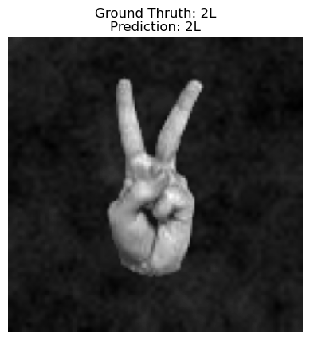

```python
# plot to see if we have the same result of the labeled dataset
plt.imshow(Image.open(BytesIO(image_data)), cmap='gray');
gt = random_test_image.split('.')[0][-2:]
label = output_object.ravel()[0]['classes'][0][0]
plt.title(f'Ground Thruth: {gt}\nPrediction: {label}')
plt.axis(False)
plt.show()
```

```python
predictor.delete_endpoint()
```

[output not shown]